# laboratorio 4

Karen del Rey y Álvaro López

17 de noviembre de 2020

# PRELABORATORIO:

## 2.1 Sistemas discretos

Creamos función polos_ceros que nos permite explorar la representación polar, respuesta en frecuencia y respuesta impulsional para diferentes valores:

```r
library(signal)
```

```r
polos_ceros <- function(r,w){
  v1 = c(1,-2*r*cos(w),r**2)
  v2 = c(1)
  zplane(v2,v1)
  x<-impz(v2,v1,100)
  plot(x)
  freqz(v2,v1)
}
```

Probamos para diferentes valores de r dejando w fijo para $\pi/2$

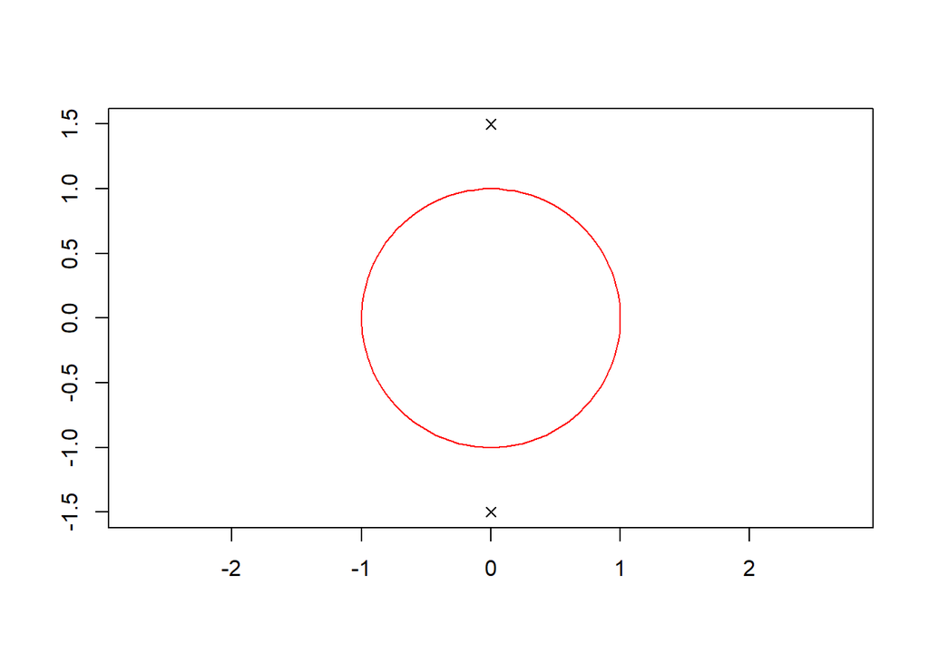

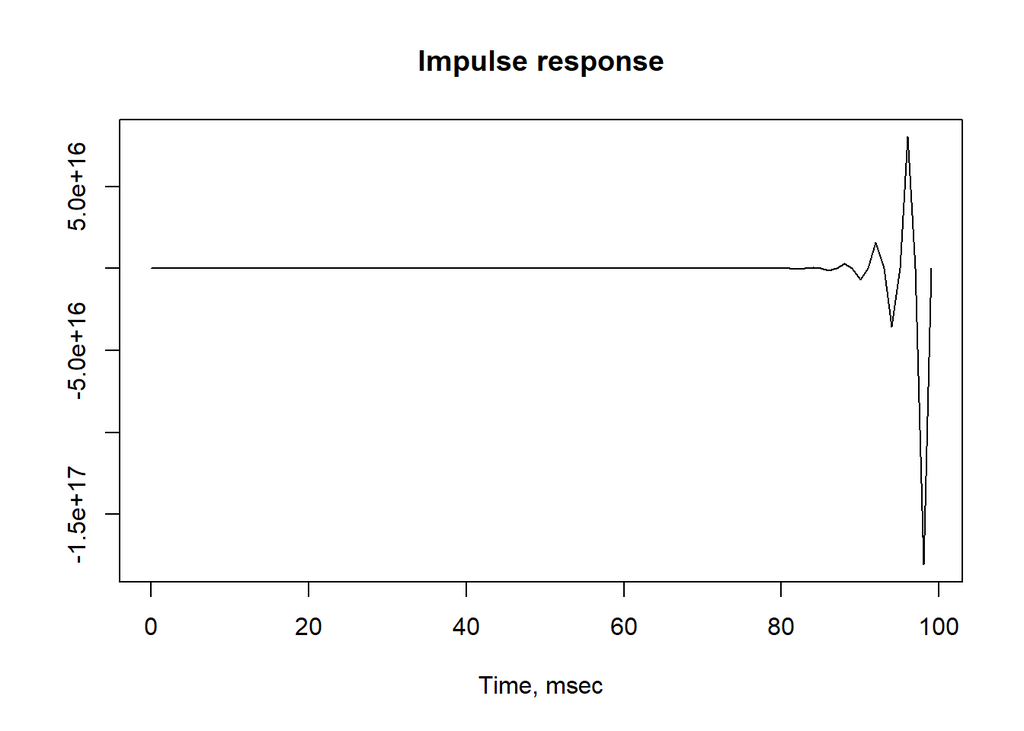

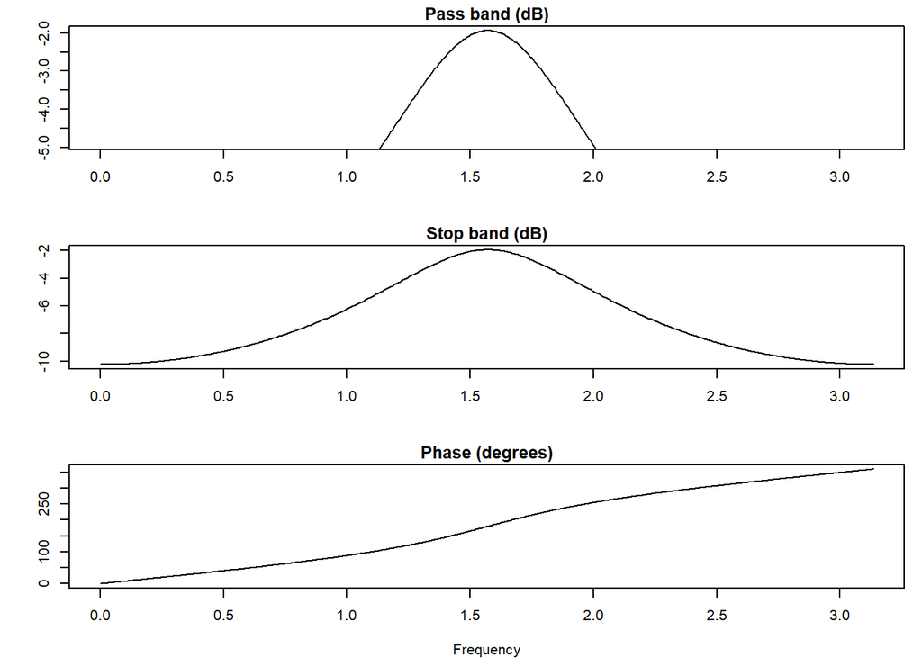

```r
# fijamos w
polos_ceros(1.5,pi/2)
```

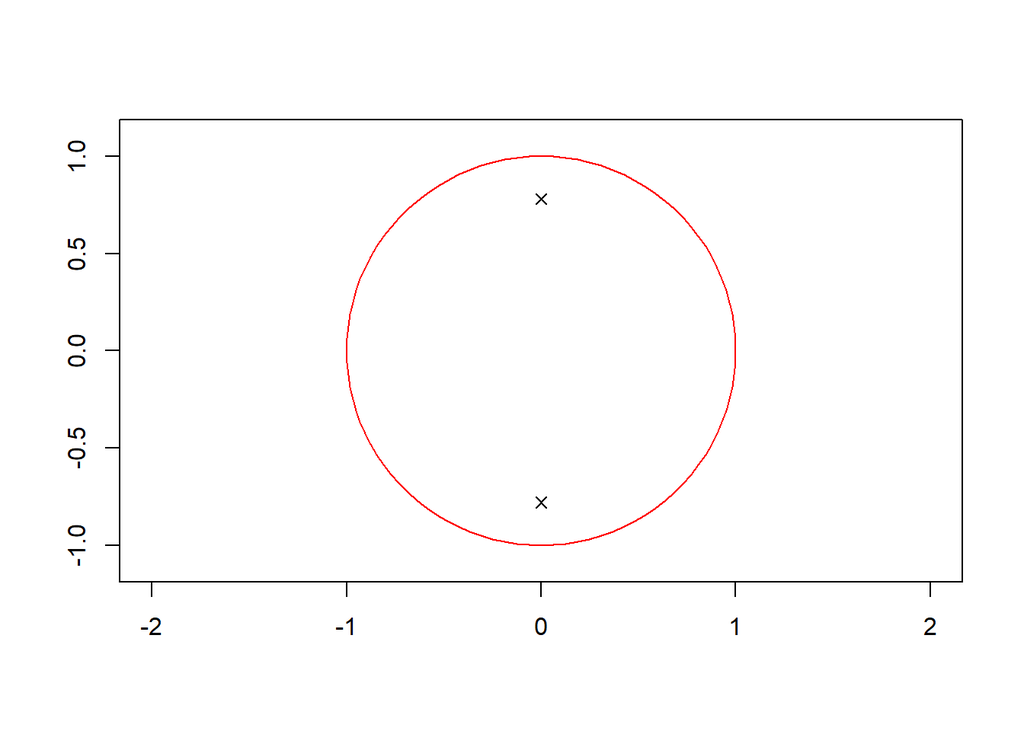

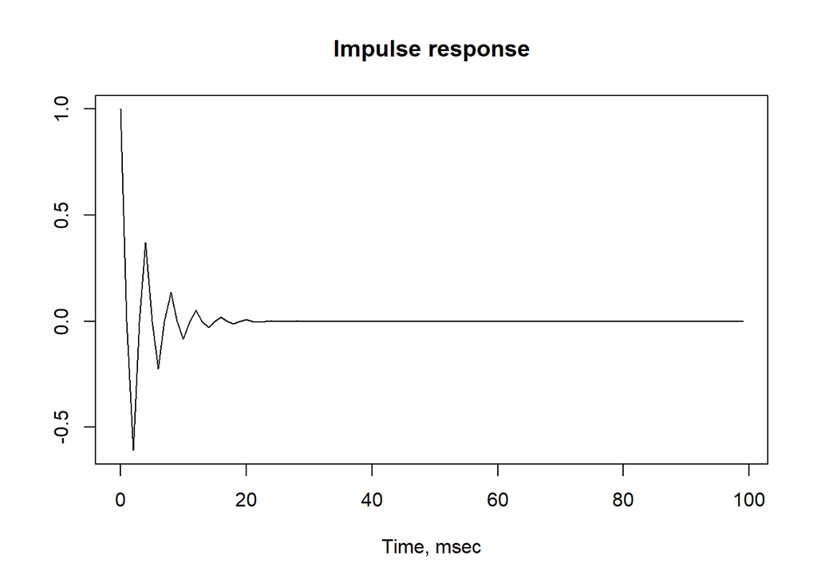

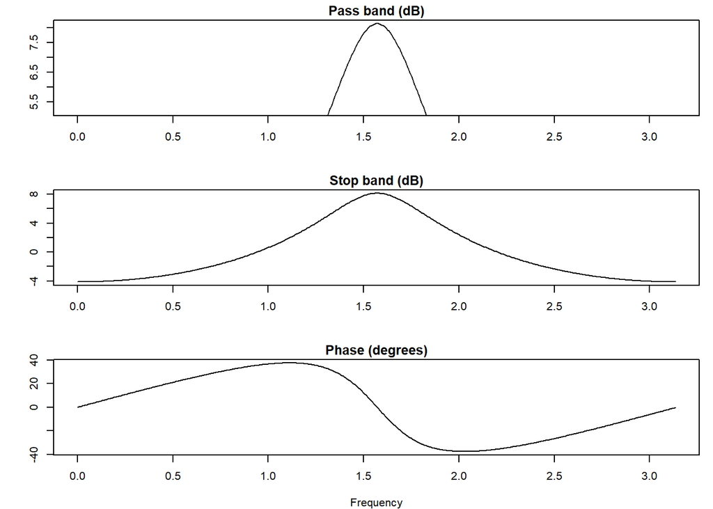

```r
polos_ceros(0.78,pi/2)
```

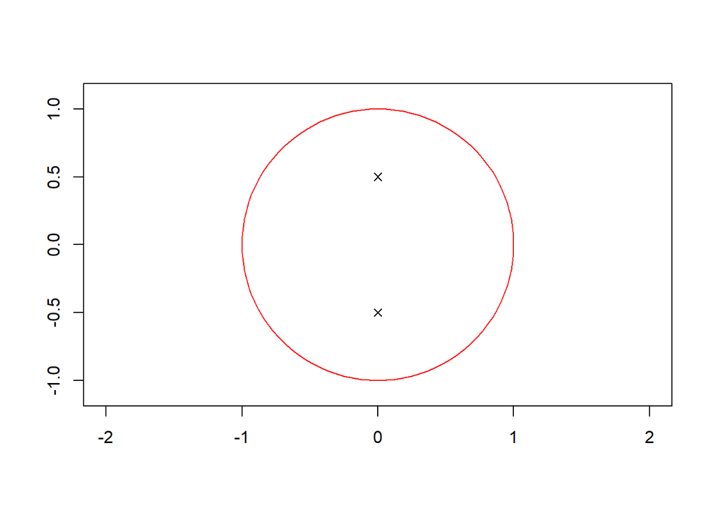

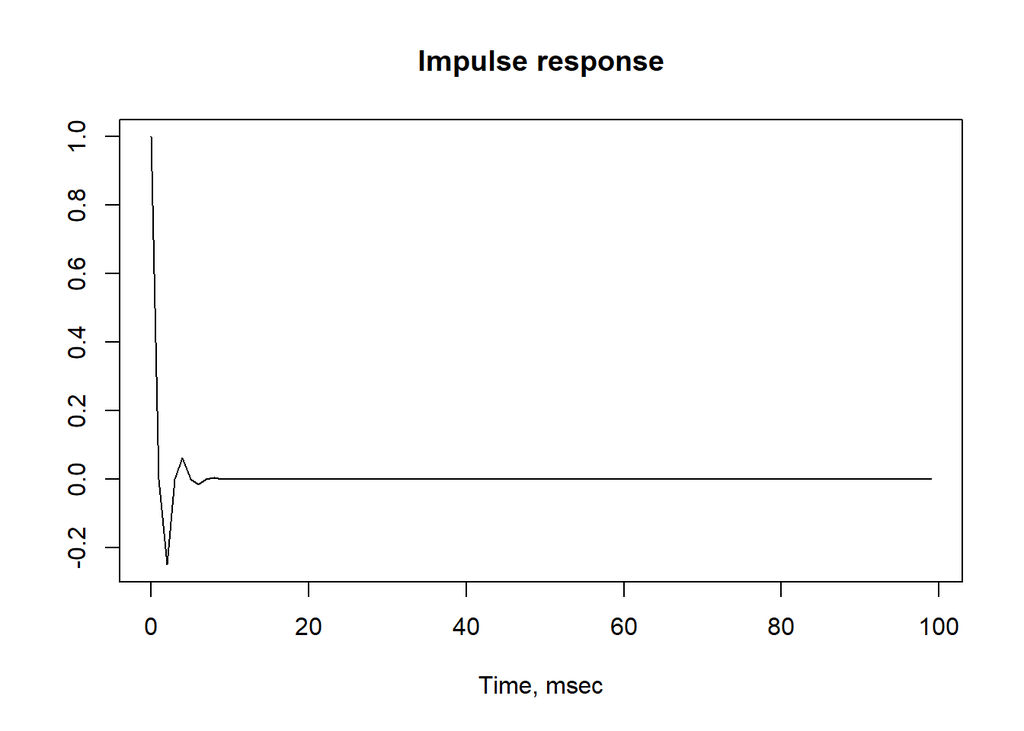

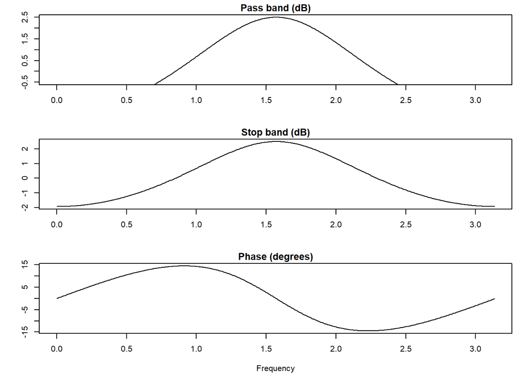

```r
polos_ceros(-0.5,pi/2)
```

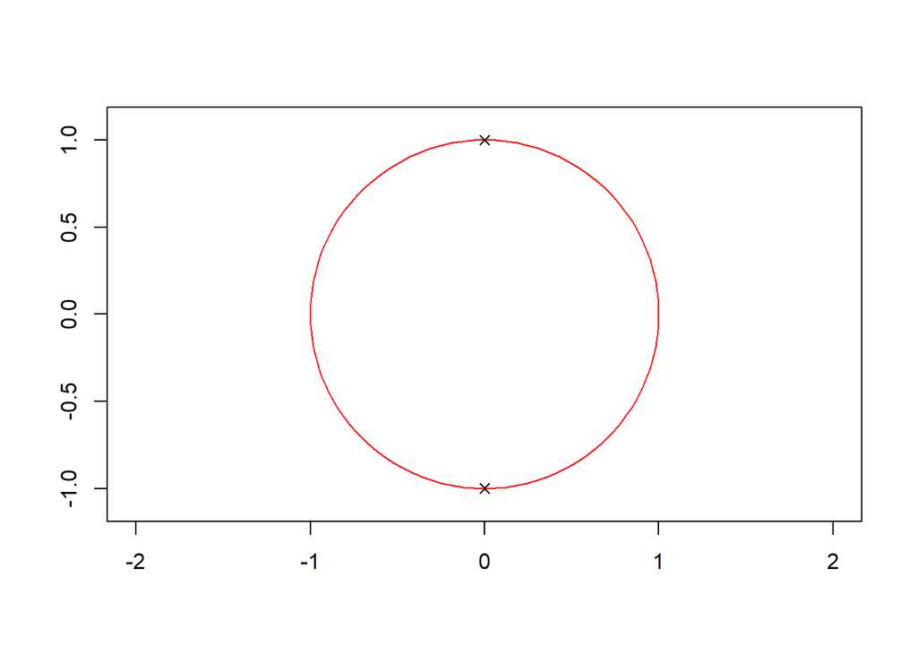

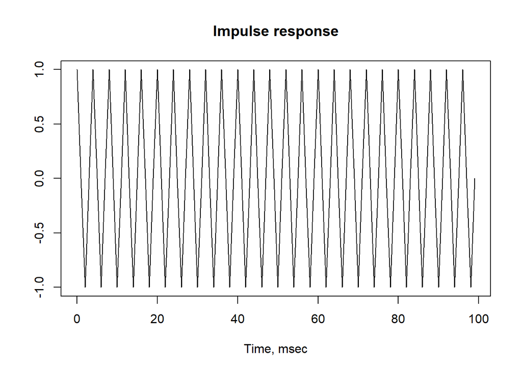

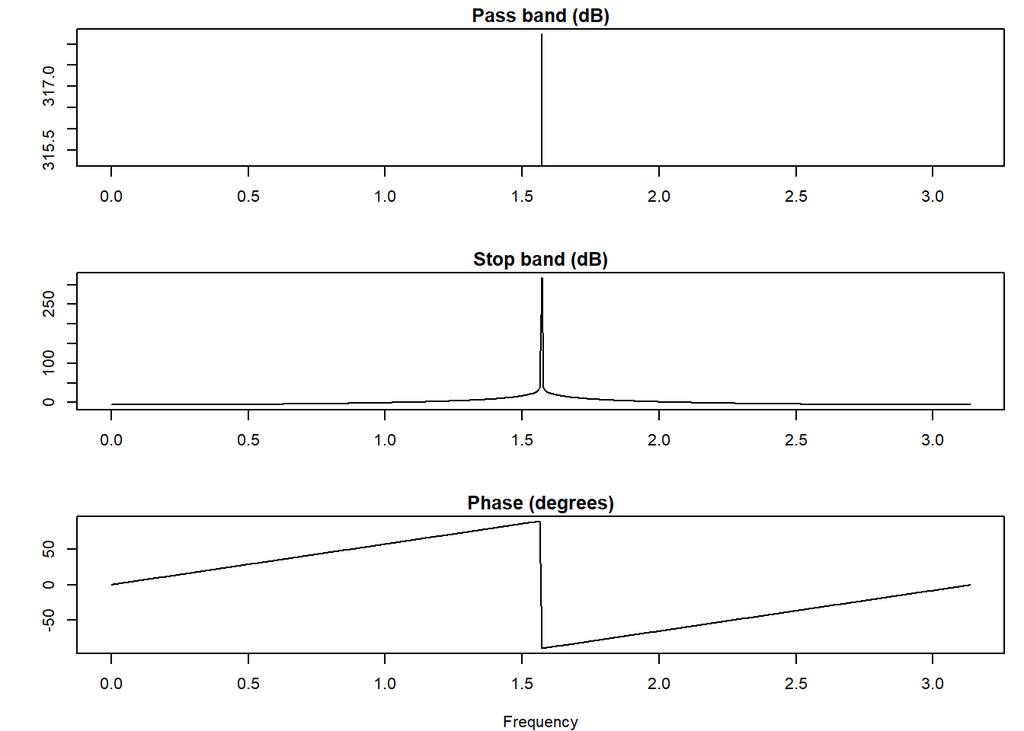

```r
polos_ceros(1,pi/2)
```

Ahora, probamos valores para una r fija:

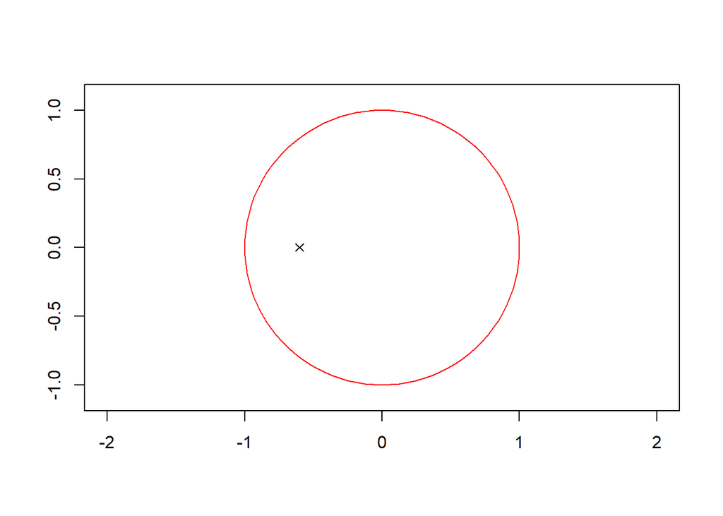

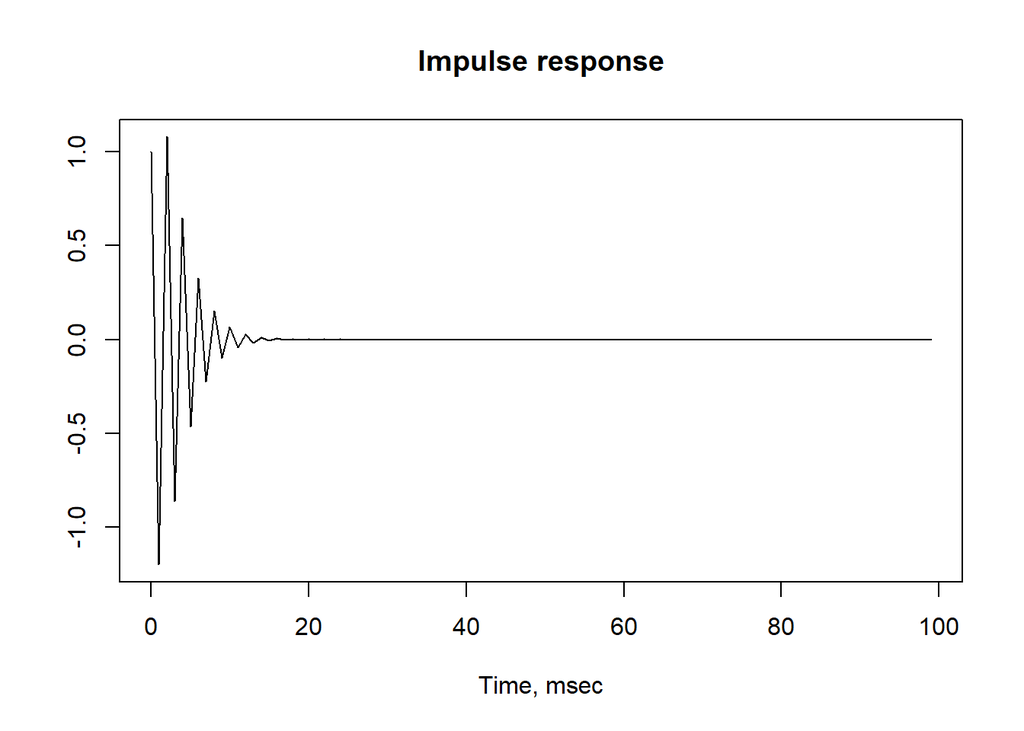

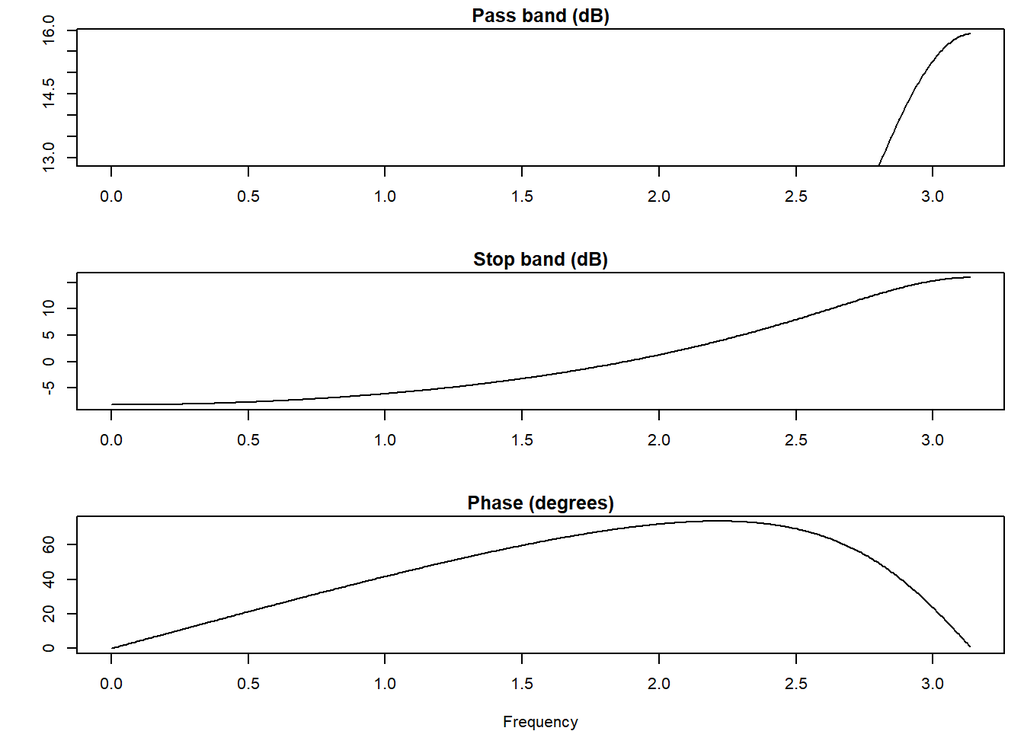

```r
# fijamos r
polos_ceros(0.6,pi)
```

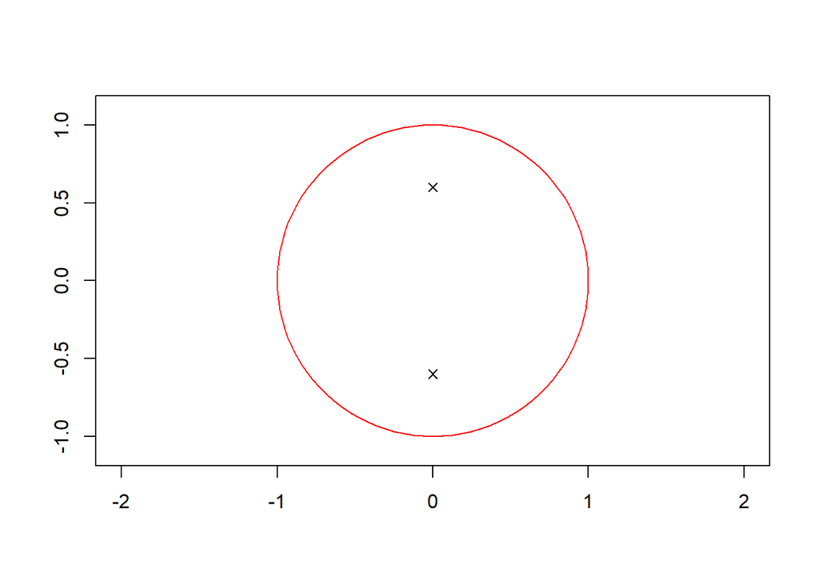

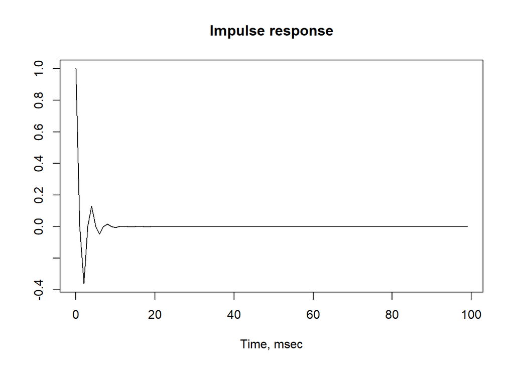

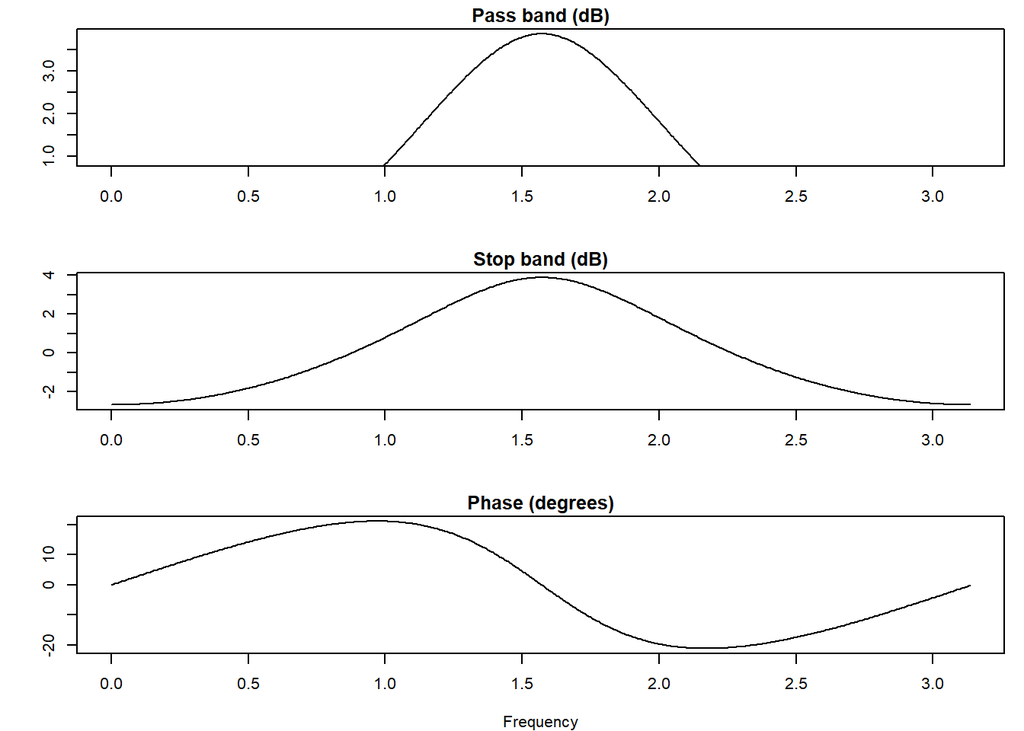

```r
polos_ceros(0.6,pi/2)
```

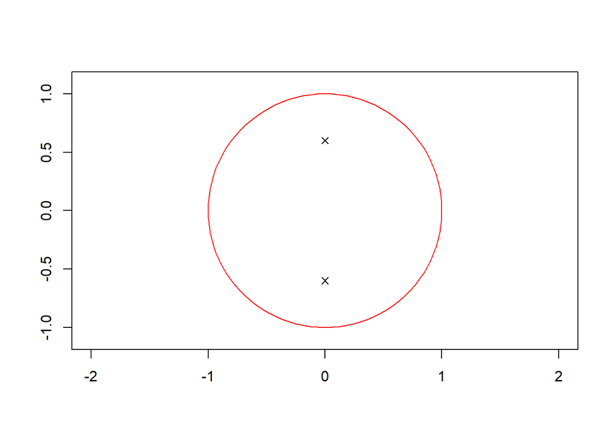

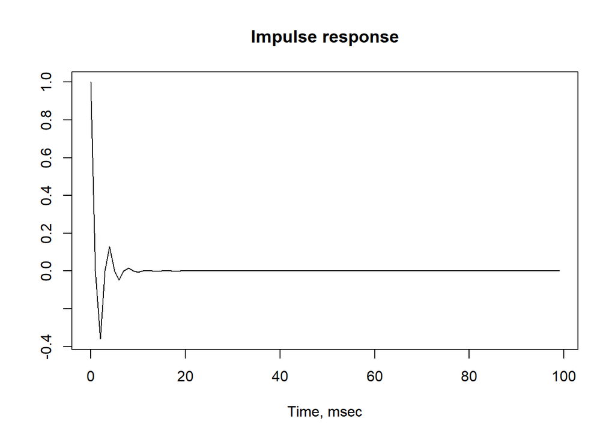

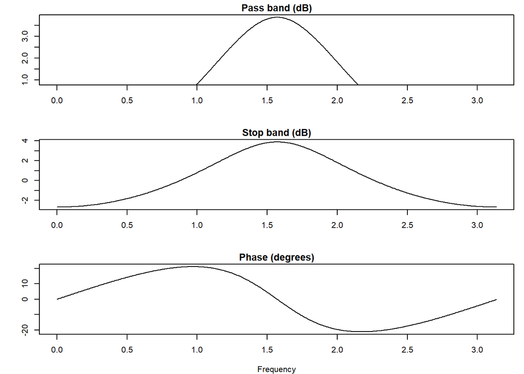

```r
polos_ceros(0.6,pi*3/2)
```

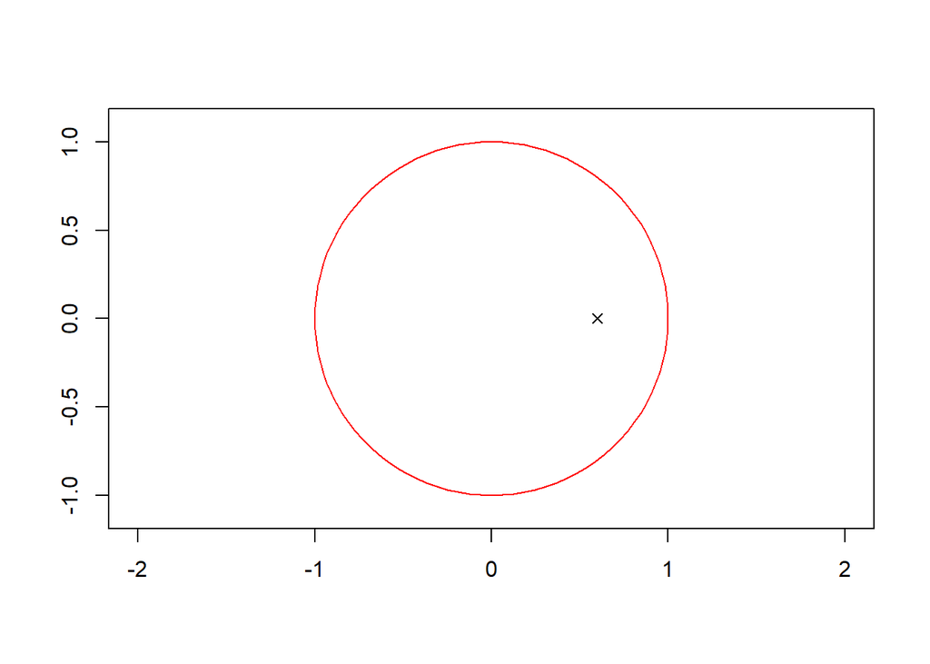

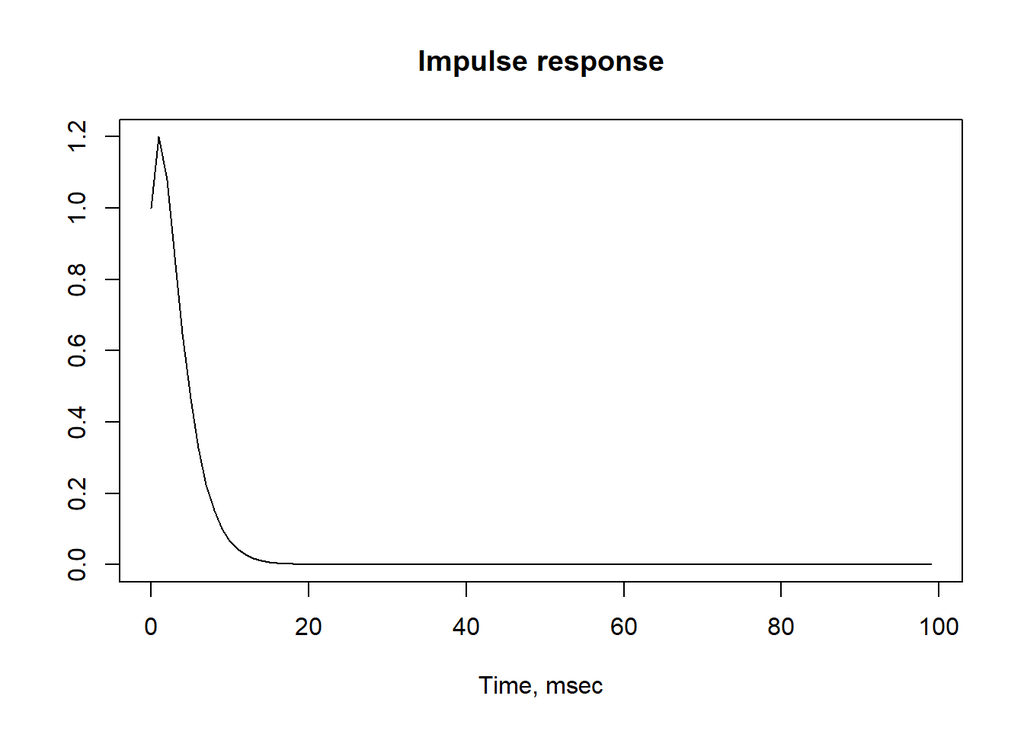

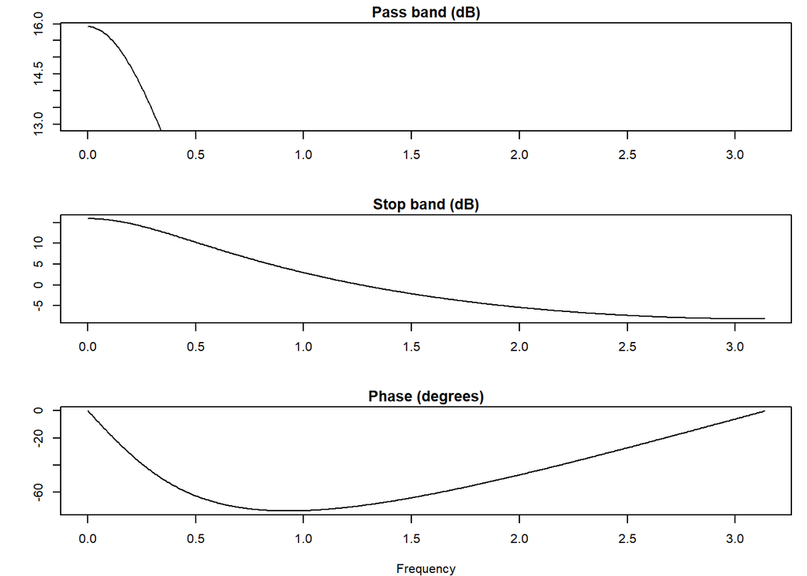

```r
polos_ceros(0.6,pi*2)
```

Para valores fijos de r observamos que al cambiar el plano cambiar la coordenadas polares. Los valores para valor absoluto r < 1 están dentro del área del círculo. Los valores de valor absoluto r = 1 caen sobre el perímetro de la circunferencia.

# LABORATORIO:

## 1.1 Sistemas discretos. Filtro peine

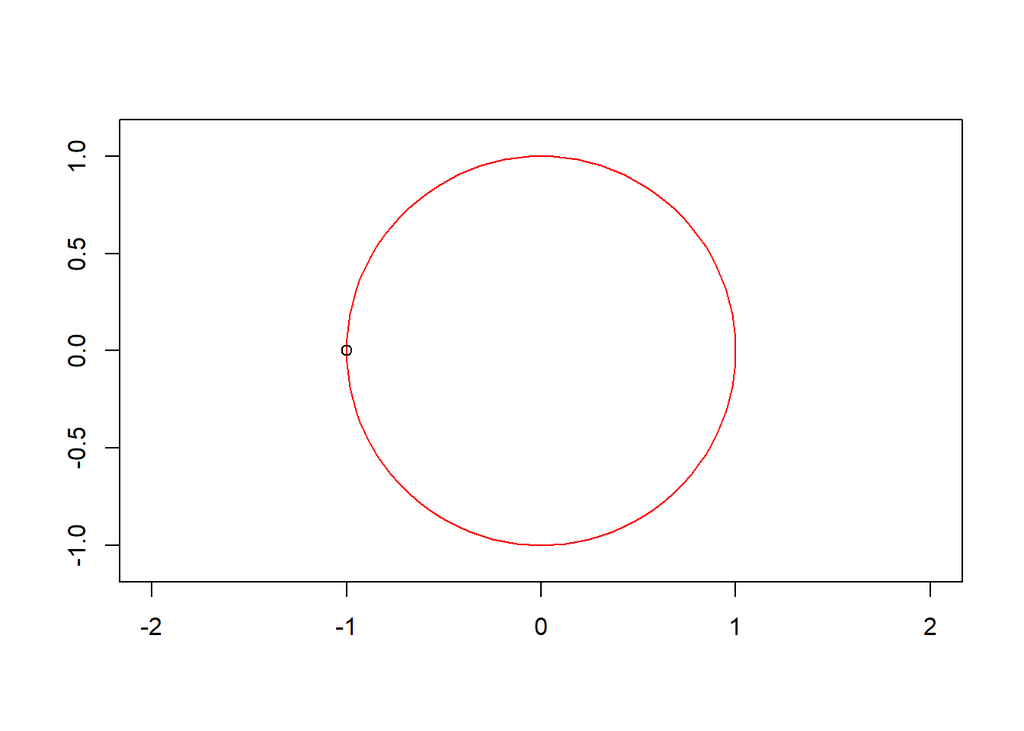

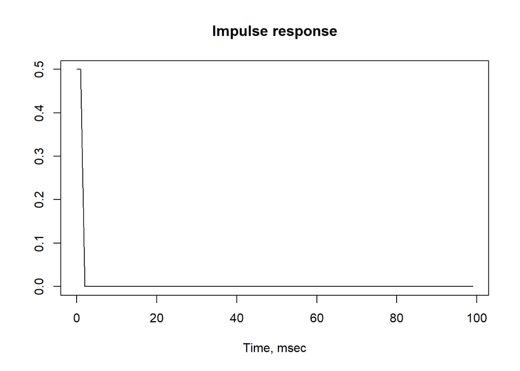

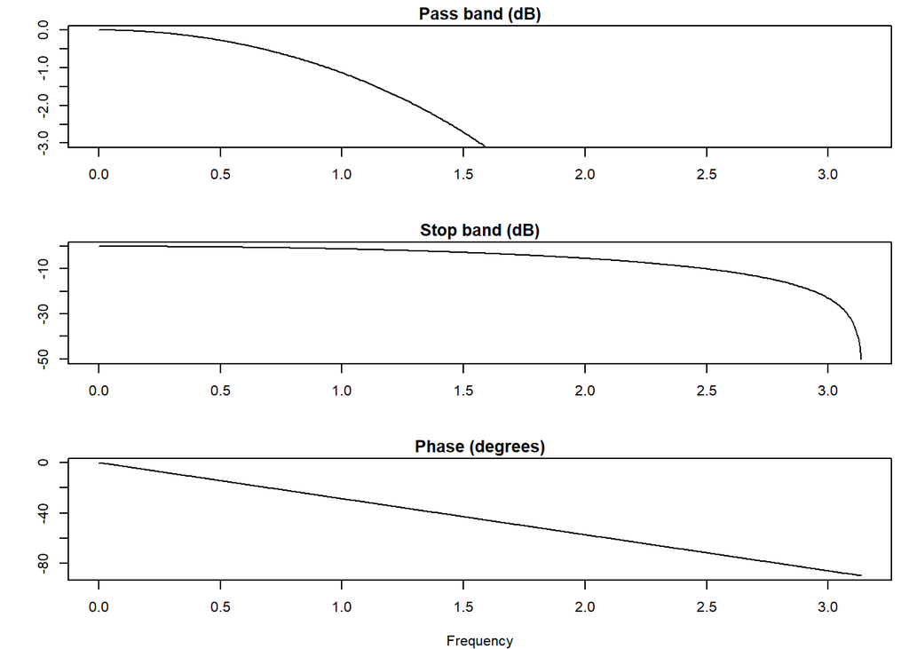

```r
library(signal)
peine <- function(N){
  v1 <- rep(1,N)  #
    v2 <- c(N)
  zplane(v1,v2) # polos
  x<- impz(v1,v2,100)
  plot(x)# respuesta impulsional
  freqz(v1,v2) # respuesta frecuencia
}
# probamos diferentes valores
peine(2)
```

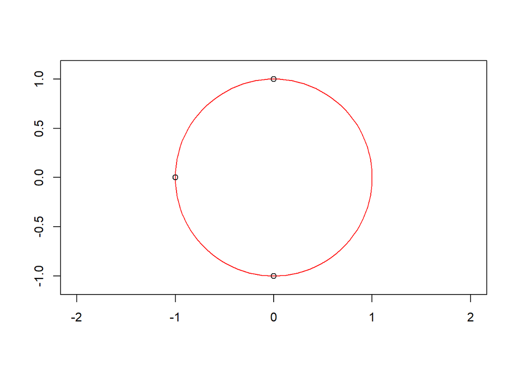

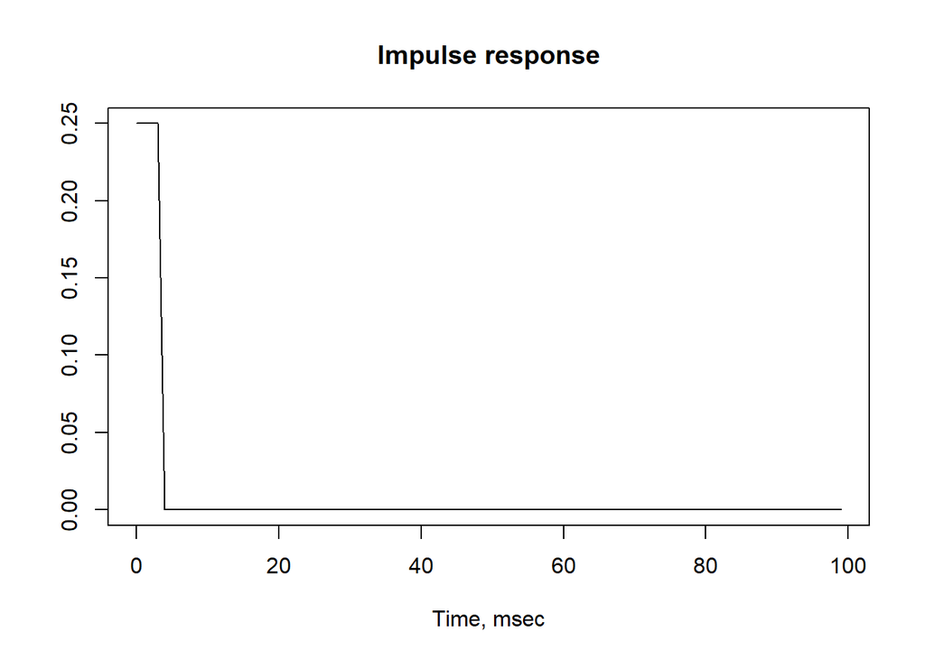

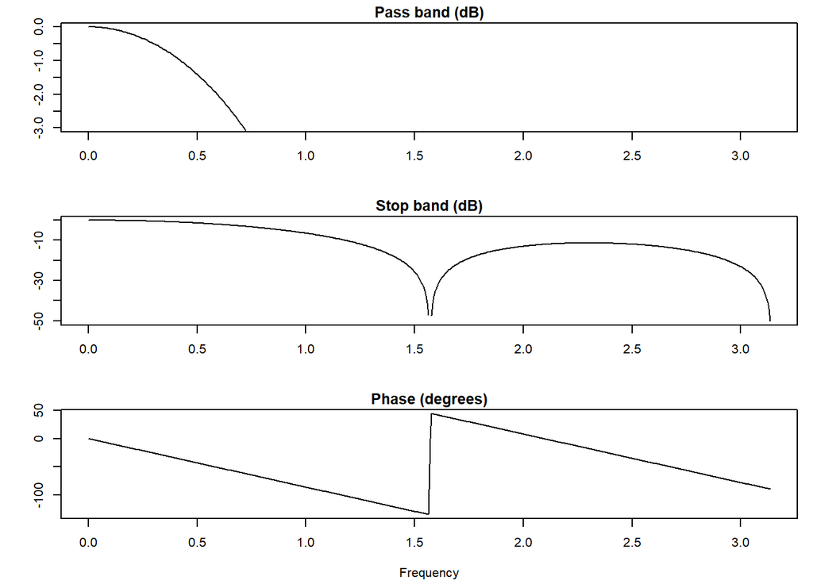

```r
peine(4)
```